# Time Series Model for Australian Resident Population Using Python

### August 28, 2019

Template Credit: Adapted from a template made available by Dr. Jason Brownlee of Machine Learning Mastery. https://machinelearningmastery.com/

SUMMARY: The purpose of this project is to construct a time series prediction model and document the end-to-end steps using a template. The Australian Resident Population dataset is a time series situation where we are trying to forecast future outcomes based on past data points.

CONCLUSION: For this dataset, the chosen ARIMA model achieved a satisfactory result and should be considered for further modeling.

Dataset Used: Quarterly Totals of Australian Resident Population

Dataset ML Model: Time series forecast with numerical attributes

Dataset Reference: https://www.alkaline-ml.com/pmdarima/modules/generated/pmdarima.datasets.load_austres.html

The project aims to touch on the following areas:

- Document a predictive modeling problem end-to-end
- Explore data cleaning and transformation options
- Explore various algorithms for baselining the model performance
- Explore tuning techniques for improving the model performance

A time series predictive modeling project genrally can be broken down into about five major tasks:

1. Define Problem and Acquire Data
2. Inspect and Explore Data
3. Clean and Pre-Process Data
4. Fit and Evaluate Models
5. Finalize Model

## Section 1. Define Problem and Acquire Data

### 1.a) Load Libraries

```python
import numpy as np
import pandas as pd
import matplotlib.pyplot as plt
import seaborn as sns
import os
import math
import smtplib
import warnings
import pmdarima as pm
from datetime import datetime
from email.message import EmailMessage
from sklearn.metrics import mean_squared_error
from statsmodels.tsa.statespace.sarimax import SARIMAX
from statsmodels.tsa.stattools import adfuller
from statsmodels.tsa.seasonal import seasonal_decompose
from statsmodels.graphics.tsaplots import plot_acf
from statsmodels.graphics.tsaplots import plot_pacf
```

### 1.b) Set up the controlling parameters and functions

```python
# Create the random seed number for reproducible results
seedNum = 888

# Set the warning message filter
warnings.filterwarnings("ignore", category=FutureWarning)
warnings.filterwarnings("ignore", category=UserWarning)

# Set up the flag to stop sending progress emails (setting to True will send status emails!)
notifyStatus = False
```

```python
# Set up the email notification function
def email_notify(msg_text):
    sender = os.environ.get('MAIL_SENDER')
    receiver = os.environ.get('MAIL_RECEIVER')
    gateway = os.environ.get('SMTP_GATEWAY')
    smtpuser = os.environ.get('SMTP_USERNAME')
    password = os.environ.get('SMTP_PASSWORD')
    if sender==None or receiver==None or gateway==None or smtpuser==None or password==None:
        sys.exit("Incomplete email setup info. Script Processing Aborted!!!")
    msg = EmailMessage()
    msg.set_content(msg_text)
    msg['Subject'] = 'Notification from Python Regression Script'
    msg['From'] = sender
    msg['To'] = receiver
    server = smtplib.SMTP(gateway, 587)
    server.starttls()
    server.login(smtpuser, password)
    server.send_message(msg)
    server.quit()
```

```python
if (notifyStatus): email_notify("Library and Data Loading has begun! "+datetime.now().strftime('%a %B %d, %Y %I:%M:%S %p'))
```

### 1.c) Acquire and Load the Data

```python
startTimeScript = datetime.now()
```

```python
# load the dataset and the necessary data structure
data_array = pm.datasets.load_austres(as_series=False)
dt_index = pd.date_range('1971-03-31', periods=len(data_array), freq='Q')
target_col = 'Residents'
series = pd.DataFrame(data=data_array, index=dt_index, columns=[target_col])
lower_bound = 'lower ' + target_col
upper_bound = 'upper ' + target_col
print('The target column of the time series is:', target_col)
print('The forecast boundary columns are:', lower_bound, '&', upper_bound)

# Back up the dataframe to a CSV file
dest_file = 'australian-residents-quarterly.csv'
if (os.path.isfile(dest_file) == False) :
    series.to_csv(dest_file)
```

```
The target column of the time series is: Residents
The forecast boundary columns are: lower Residents & upper Residents
```

```python
series.info()
```

```
<class 'pandas.core.frame.DataFrame'>
DatetimeIndex: 89 entries, 1971-03-31 to 1993-03-31
Freq: Q-DEC
Data columns (total 1 columns):
Residents    89 non-null float64
dtypes: float64(1)
memory usage: 1.4 KB
```

```python
series.head(10)
```

|  | Residents |
| --- | --- |
| 1971-03-31 | 13067.3 |
| 1971-06-30 | 13130.5 |
| 1971-09-30 | 13198.4 |
| 1971-12-31 | 13254.2 |
| 1972-03-31 | 13303.7 |
| 1972-06-30 | 13353.9 |
| 1972-09-30 | 13409.3 |
| 1972-12-31 | 13459.2 |
| 1973-03-31 | 13504.5 |
| 1973-06-30 | 13552.6 |

```python
series.tail(10)
```

|  | Residents |
| --- | --- |
| 1990-12-31 | 17239.4 |
| 1991-03-31 | 17292.0 |
| 1991-06-30 | 17354.2 |
| 1991-09-30 | 17414.2 |
| 1991-12-31 | 17447.3 |
| 1992-03-31 | 17482.6 |
| 1992-06-30 | 17526.0 |
| 1992-09-30 | 17568.7 |
| 1992-12-31 | 17627.1 |
| 1993-03-31 | 17661.5 |

```python
if (notifyStatus): email_notify("Library and Data Loading completed! "+datetime.now().strftime('%a %B %d, %Y %I:%M:%S %p'))
```

## Section 2. Inspect and Explore Data

```python
if (notifyStatus): email_notify("Data Inspection and Exploration has begun! "+datetime.now().strftime('%a %B %d, %Y %I:%M:%S %p'))
```

### 2.a) Summary Statistics of the Time Series Data

Summary statistics provide a quick look at the limits of observed values. It can help to get a quick idea of what we are working with.

```python
# Summary statistics of time series
print(series.describe())
```

```
          Residents
count     89.000000
mean   15273.449438
std     1356.812524
min    13067.300000
25%    14110.100000
50%    15184.200000
75%    16398.900000
max    17661.500000
```

### 2.b) Line Plot of the Time Series Data

A line plot of a time series can provide a lot of insight into the problem. Some observations from the plot can include:

- Whether the trend appears to be level around the mean
- Whether there appear to be any obvious outliers

The ARIMA(p,d,q) model requires three parameters and assumes that we are working with a stationary time series.

The ADF results should show that the test statistic value is smaller than the critical value at 5% if the time series is stationary. This suggests that we can reject the null hypothesis (i.e. a low probability that the result is a statistical fluke).

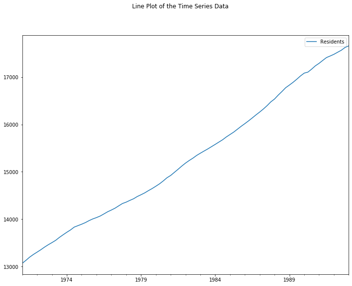

```python
# Line plots of time series
fig, ax = plt.subplots(figsize=(12,9))
fig.suptitle('Line Plot of the Time Series Data')
series.plot(ax=ax)
plt.show()
```

### 2.c) ACF and PACF Plots of the Time Series Data

The next first step is to select the lag values for the Autoregression (AR) and Moving Average (MA) parameters, p and q respectively. We can get some good ideas by reviewing Autocorrelation Function (ACF) and Partial Autocorrelation Function (PACF) plots.

```python
# Check if stationary
result = adfuller(series[target_col])
print('ADF Statistic: %f' % result[0])
print('p-value: %f' % result[1])
print('Critical Test Statistics Values:')
for key, value in result[4].items():
    print('\t%s: %.3f' % (key, value))
```

```
ADF Statistic: 0.517268
p-value: 0.985389
Critical Test Statistics Values:
	1%: -3.511
	5%: -2.897
	10%: -2.585
```

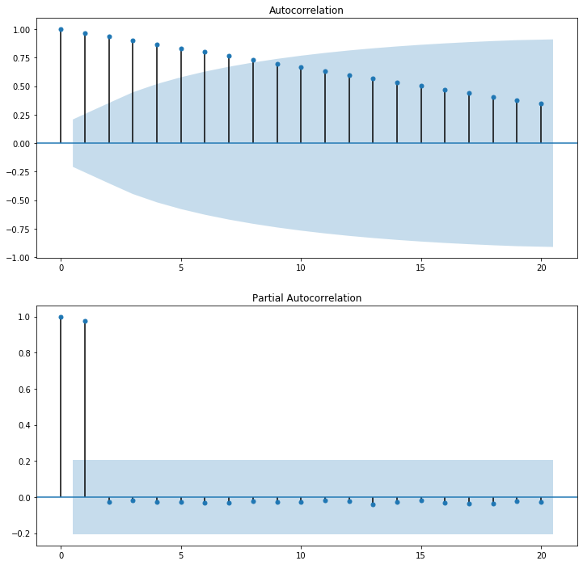

```python
# ACF and PACF plots of the time series data
fig, (ax1, ax2) = plt.subplots(2, 1, figsize=(12,12))
plot_acf(series, ax=ax1)
plot_pacf(series, ax=ax2)
plt.show()
```

### 2.d) Histogram and Density Plots of the Time Series Data

Reviewing plots of the density of observations can provide further insight into the structure of the data. Some observations from the plots can include:

- Whether the distribution is Gaussian
- Whether the distribution has a long tail and may suggest the need for data transformation

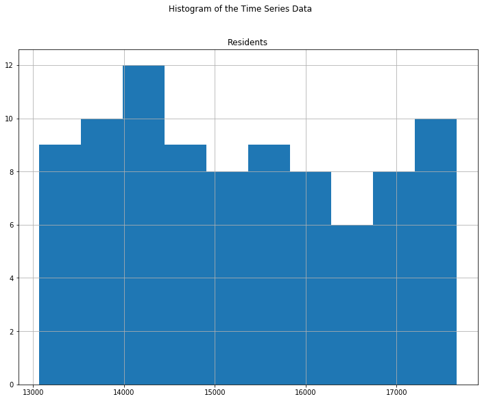

```python
# Line plots of time series
fig, ax = plt.subplots(figsize=(12,9))
fig.suptitle('Histogram of the Time Series Data')
series.hist(ax=ax)
plt.show()
```

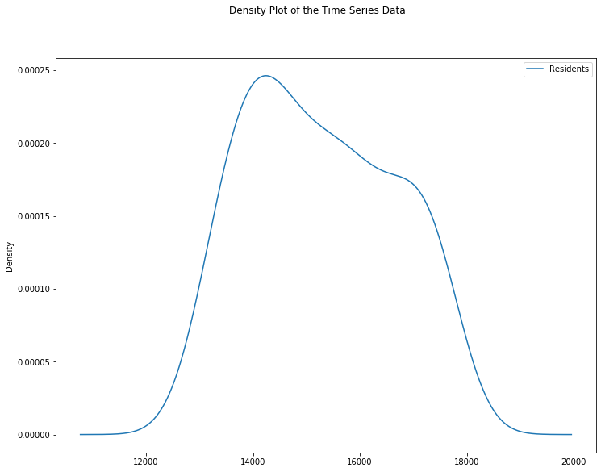

```python
# Line plots of time series
fig, ax = plt.subplots(figsize=(12,9))
fig.suptitle('Density Plot of the Time Series Data')
series.plot(kind='kde', ax=ax)
plt.show()
```

### 2.e) Box and Whisker Plots of the Time Series Data

We can group or aggregate the data and get a better idea of the spread of observations. Some observations from reviewing the plot can include:

- Whether the median values for each grouping shows any significant trend
- Whether the spread, or middle 50% of the data, shows any significant variability
- Whether there are outliers in some grouping

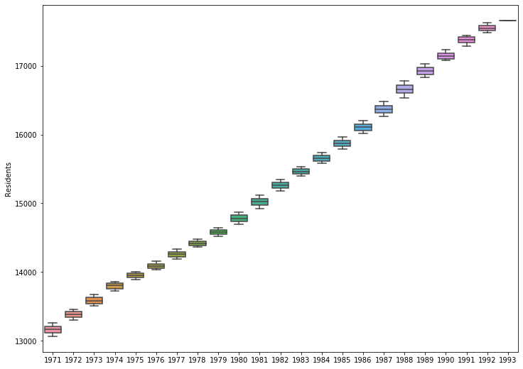

```python
# boxplots of time series
fig, ax = plt.subplots(figsize=(12,9))
squeezed = series.squeeze()
sns.boxplot(squeezed.index.year, squeezed, ax=ax)
plt.show()
```

### 2.f) Seasonal Decomposition for Seasonal Time Series Data

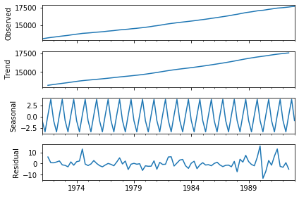

```python
# Perform seasonal decomposition to observe the seasonal frequency
decomp_results = seasonal_decompose(series)
decomp_results.plot()
plt.show()
```

```python
# Detrending the time series
N = 24
detrend = series - series.rolling(N).mean()
detrend = detrend.dropna()
```

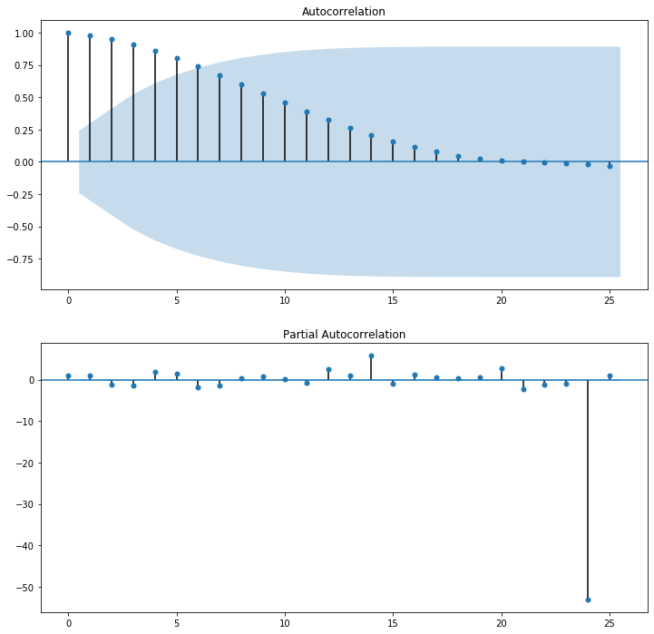

```python
# ACF and PACF plots of the time series data
fig, (ax1, ax2) = plt.subplots(2, 1, figsize=(12,12))
plot_acf(detrend, lags=25, ax=ax1)
plot_pacf(detrend, lags=25, ax=ax2)
plt.show()
```

```python
# Set the seasonal frequency parameter for later uses in the script
seasonal_freq = 4
```

### 2.g) Test for Stationarity of Non-Seasonal Time Series Data

Occasionally a time series may look non-stationary on the first look. We can make it stationary by differencing the series and using a statistical test to confirm that the differenced result is stationary. Rejecting the null hypothesis means that the process has no unit root, and in turn that the time series is stationary or does not have time-dependent structure.

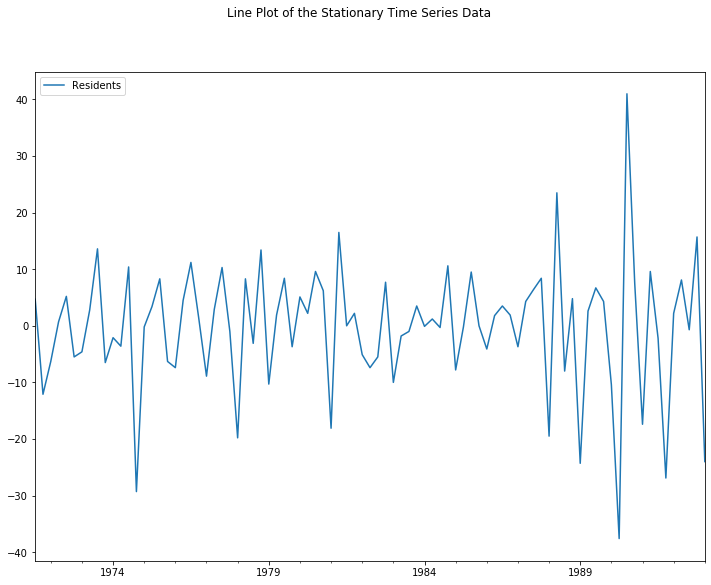

```python
# Create a differenced series
stationary_ns = series.diff().diff().dropna()

# Plot differenced data
fig, ax = plt.subplots(figsize=(12,9))
fig.suptitle('Line Plot of the Stationary Time Series Data')
stationary_ns.plot(ax=ax)
plt.show()
```

```python
# Check for stationarity
result = adfuller(stationary_ns[target_col])
print('ADF Statistic: %f' % result[0])
print('p-value: %f' % result[1])
print('Critical Test Statistics Values:')
for key, value in result[4].items():
    print('\t%s: %.3f' % (key, value))
```

```
ADF Statistic: -8.872347
p-value: 0.000000
Critical Test Statistics Values:
	1%: -3.511
	5%: -2.897
	10%: -2.585
```

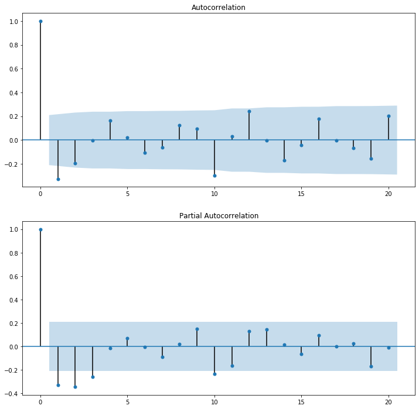

```python
# ACF and PACF plots of the stationary time series
fig, (ax1, ax2) = plt.subplots(2, 1, figsize=(12,12))
plot_acf(stationary_ns, ax=ax1)
plot_pacf(stationary_ns, ax=ax2)
plt.show()
```

```python
# Set the p, d, and q order parameters for later uses in the script
start_p = 1
order_d = 2
start_q = 1
max_p = 5
max_q = 5
```

### 2.h) Test for Stationarity of Seasonal Time Series Data

Occasionally a time series may look non-stationary on the first look. We can make it stationary by differencing the series and using a statistical test to confirm that the differenced result is stationary. Rejecting the null hypothesis means that the process has no unit root, and in turn that the time series is stationary or does not have time-dependent structure.

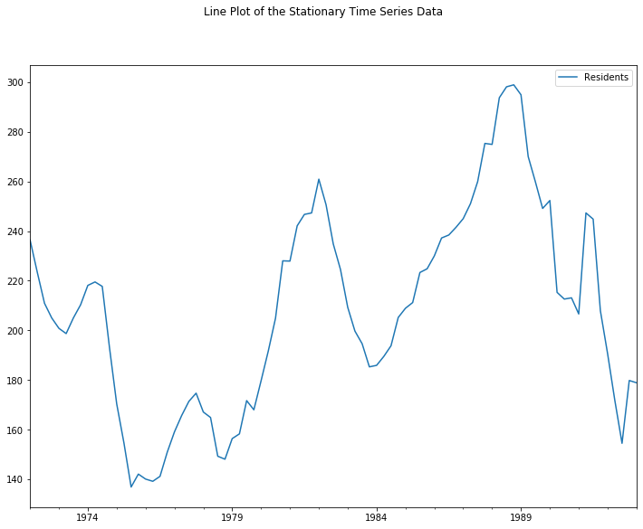

```python
# Create a differenced series
stationary_ss = series.diff(seasonal_freq).dropna()

# Plot differenced data
fig, ax = plt.subplots(figsize=(12,9))
fig.suptitle('Line Plot of the Stationary Time Series Data')
stationary_ss.plot(ax=ax)
plt.show()
```

```python
# Check for stationarity
result = adfuller(stationary_ss[target_col])
print('ADF Statistic: %f' % result[0])
print('p-value: %f' % result[1])
print('Critical Test Statistics Values:')
for key, value in result[4].items():
    print('\t%s: %.3f' % (key, value))
```

```
ADF Statistic: -2.335930
p-value: 0.160642
Critical Test Statistics Values:
	1%: -3.522
	5%: -2.901
	10%: -2.588
```

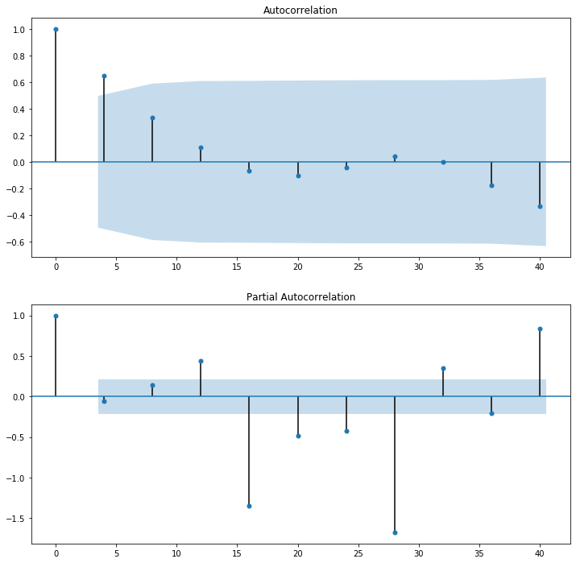

```python
# ACF and PACF plots of the stationary time series
lags = [0, 4, 8, 12, 16, 20, 24, 28, 32, 36, 40]
fig, (ax1, ax2) = plt.subplots(2, 1, figsize=(12,12))
plot_acf(stationary_ss, lags=lags, ax=ax1)
plot_pacf(stationary_ss, lags=lags, ax=ax2)
plt.show()
```

```python
# Set the P, D, and Q order parameters for later uses in the script
start_P = 0
order_D = 1
start_Q = 0
max_P = 3
max_Q = 3
```

```python
if (notifyStatus): email_notify("Data Inspection and Exploration completed! "+datetime.now().strftime('%a %B %d, %Y %I:%M:%S %p'))
```

## Section 3. Clean and Pre-Process Data

```python
if (notifyStatus): email_notify("Data Cleaning and Pre-Processing has begun! "+datetime.now().strftime('%a %B %d, %Y %I:%M:%S %p'))
```

This section currently is not applicable to this iteration of the project.

```python
if (notifyStatus): email_notify("Data Cleaning and Pre-Processing completed! "+datetime.now().strftime('%a %B %d, %Y %I:%M:%S %p'))
```

## Section 4. Fit and Evaluate Models

In this section, we will develop Autoregressive Integrated Moving Average or ARIMA models for the problem. We will first establish a persistent model. Next we will use a grid search approach to look for an optimal ARIMA model. This will be followed by a third step of investigating the residual errors of the chosen model.

- Establish the Persistent Model
- Automatically Configure the ARIMA
- Review Residual Errors

```python
if (notifyStatus): email_notify("Model Fitting and Evaluation has begun! "+datetime.now().strftime('%a %B %d, %Y %I:%M:%S %p'))
```

### 4.a) Establish the Persistent Model

The first step before getting bogged down in data analysis and modeling is to establish a baseline of performance. This will provide both a template for evaluating models using the proposed test harness and a performance measure by which all more elaborate predictive models can be compared.

The baseline prediction for time series forecasting is called the naive forecast, or persistence. This is where the observation from the previous time step is used as the prediction for the observation at the next time step.

#### 4.a.iii) Establish the Persistent Model as Baseline

```python
# Prepare and evaluate a persistence model
X = series.values
X = X.astype('float32')
train_pct = 0.75
train_size = int(len(X) * train_pct)
test_size = len(X) - train_size
train, test = X[0:train_size], X[train_size:]

# walk-forward validation
history = [x for x in train]
predictions = list()
for i in range(len(test)):
    yhat = history[-1]
    predictions.append(yhat)
    obs = test[i]
    history.append(obs)
    print('>Predicted=%.3f, Expected=%3.f' % (yhat, obs))

# Calculate performance
rmse = math.sqrt(mean_squared_error(test, predictions))
print('RMSE for the persistent model is: %.3f' % rmse)
```

```
>Predicted=16327.900, Expected=16399
>Predicted=16398.900, Expected=16478
>Predicted=16478.301, Expected=16538
>Predicted=16538.199, Expected=16622
>Predicted=16621.600, Expected=16697
>Predicted=16697.000, Expected=16777
>Predicted=16777.199, Expected=16833
>Predicted=16833.100, Expected=16892
>Predicted=16891.600, Expected=16957
>Predicted=16956.801, Expected=17026
>Predicted=17026.301, Expected=17085
>Predicted=17085.400, Expected=17107
>Predicted=17106.900, Expected=17169
>Predicted=17169.400, Expected=17239
>Predicted=17239.400, Expected=17292
>Predicted=17292.000, Expected=17354
>Predicted=17354.199, Expected=17414
>Predicted=17414.199, Expected=17447
>Predicted=17447.301, Expected=17483
>Predicted=17482.600, Expected=17526
>Predicted=17526.000, Expected=17569
>Predicted=17568.699, Expected=17627
>Predicted=17627.100, Expected=17662
RMSE for the persistent model is: 60.171
```

### 4.b) Grid Search of ARIMA Hyperparameters

We want to find a model that can do better than the persistence model on this dataset. To confirm this analysis, we can grid search a suite of ARIMA hyperparameters.

In this section, we will search values of p, d, and q for combinations (skipping those that fail to converge), and find the combination that results in the best performance. We will use a grid search to explore all combinations in a subset of integer values.

```python
if (notifyStatus): email_notify("ARIMA Hyperparameters Search has begun! "+datetime.now().strftime('%a %B %d, %Y %I:%M:%S %p'))
```

```python
# Do a grid search ARIMA parameters for a time series
print('The suggested non-seasonal differencing term is:', pm.arima.ndiffs(series))
if (seasonal_freq > 0): print('The suggested seasonal differencing term is:', pm.arima.nsdiffs(series, m = seasonal_freq))
if (seasonal_freq == 0): results = pm.auto_arima(series, d = order_d, start_p = start_p, start_q = start_q, max_p = max_p, max_q = max_q,
                                                seasonal = False, information_criterion = 'aic', trace = True, error_action = 'ignore', stepwise = True, n_jobs = 1)
else:
    results = pm.auto_arima(series, d = order_d, start_p = start_p, start_q = start_q, max_p = max_p, max_q = max_q,
                            seasonal = True, m = seasonal_freq, D = order_D, start_P = start_P, start_Q = start_Q,
                            max_P = max_P, max_Q = max_Q, information_criterion = 'aic', trace = True,
                            error_action = 'ignore', stepwise = True, n_jobs = 1)
```

```
The suggested non-seasonal differencing term is: 2
The suggested seasonal differencing term is: 0
Fit ARIMA: order=(1, 2, 1) seasonal_order=(0, 1, 0, 4); AIC=659.834, BIC=669.510, Fit time=0.258 seconds
Fit ARIMA: order=(0, 2, 0) seasonal_order=(0, 1, 0, 4); AIC=685.366, BIC=690.203, Fit time=0.012 seconds
Fit ARIMA: order=(1, 2, 0) seasonal_order=(1, 1, 0, 4); AIC=654.381, BIC=664.056, Fit time=0.109 seconds
Fit ARIMA: order=(0, 2, 1) seasonal_order=(0, 1, 1, 4); AIC=622.579, BIC=632.254, Fit time=0.111 seconds
Fit ARIMA: order=(0, 2, 1) seasonal_order=(1, 1, 1, 4); AIC=624.574, BIC=636.669, Fit time=0.212 seconds
Fit ARIMA: order=(0, 2, 1) seasonal_order=(0, 1, 0, 4); AIC=665.397, BIC=672.653, Fit time=0.053 seconds
Fit ARIMA: order=(0, 2, 1) seasonal_order=(0, 1, 2, 4); AIC=624.573, BIC=636.667, Fit time=0.156 seconds
Fit ARIMA: order=(0, 2, 1) seasonal_order=(1, 1, 2, 4); AIC=625.572, BIC=640.085, Fit time=0.280 seconds
Fit ARIMA: order=(1, 2, 1) seasonal_order=(0, 1, 1, 4); AIC=624.554, BIC=636.648, Fit time=0.207 seconds
Fit ARIMA: order=(0, 2, 0) seasonal_order=(0, 1, 1, 4); AIC=640.081, BIC=647.338, Fit time=0.067 seconds
Fit ARIMA: order=(0, 2, 2) seasonal_order=(0, 1, 1, 4); AIC=624.553, BIC=636.647, Fit time=0.157 seconds
Fit ARIMA: order=(1, 2, 2) seasonal_order=(0, 1, 1, 4); AIC=626.534, BIC=641.047, Fit time=0.501 seconds
Total fit time: 2.129 seconds
```

```python
print(results.summary())
```

```
                                 Statespace Model Results
=========================================================================================
Dep. Variable:                                 y   No. Observations:                   89
Model:             SARIMAX(0, 2, 1)x(0, 1, 1, 4)   Log Likelihood                -307.289
Date:                           Mon, 19 Aug 2019   AIC                            622.579
Time:                                   20:40:19   BIC                            632.254
Sample:                                        0   HQIC                           626.466
                                            - 89
Covariance Type:                             opg
==============================================================================
                 coef    std err          z      P>|z|      [0.025      0.975]
------------------------------------------------------------------------------
intercept      0.0057      0.109      0.052      0.958      -0.207       0.219
ma.L1         -0.5113      0.112     -4.564      0.000      -0.731      -0.292
ma.S.L4       -0.9406      0.117     -8.036      0.000      -1.170      -0.711
sigma2        86.3804     11.631      7.427      0.000      63.585     109.176
===================================================================================
Ljung-Box (Q):                       17.43   Jarque-Bera (JB):               122.64
Prob(Q):                              1.00   Prob(JB):                         0.00
Heteroskedasticity (H):               3.09   Skew:                            -1.59
Prob(H) (two-sided):                  0.00   Kurtosis:                         8.03
===================================================================================

Warnings:
[1] Covariance matrix calculated using the outer product of gradients (complex-step).
```

```python
# Set the optimal ARIMA order parameters for later uses in the script
ns_order = (0, 2, 1)
ss_order = (0, 0, 0, 0)
```

```python
if (notifyStatus): email_notify("ARIMA Hyperparameters Search completed! "+datetime.now().strftime('%a %B %d, %Y %I:%M:%S %p'))
```

### 4.c) Evaluate the Residual Errors

A good final check of a model is to review residual forecast errors. Ideally, the distribution of residual errors should be a Gaussian with a zero mean.

```
                           Statespace Model Results
==============================================================================
Dep. Variable:              Residents   No. Observations:                   89
Model:               SARIMAX(0, 2, 1)   Log Likelihood                -324.419
Date:                Mon, 19 Aug 2019   AIC                            654.838
Time:                        20:40:19   BIC                            662.236
Sample:                    03-31-1971   HQIC                           657.817
                         - 03-31-1993
Covariance Type:                  opg
==============================================================================
                 coef    std err          z      P>|z|      [0.025      0.975]
------------------------------------------------------------------------------
intercept     -0.2108      0.509     -0.414      0.679      -1.209       0.788
ma.L1         -0.5923      0.082     -7.230      0.000      -0.753      -0.432
sigma2       100.9115     11.829      8.531      0.000      77.728     124.096
===================================================================================
Ljung-Box (Q):                       51.39   Jarque-Bera (JB):                35.33
Prob(Q):                              0.11   Prob(JB):                         0.00
Heteroskedasticity (H):               2.34   Skew:                            -1.01
Prob(H) (two-sided):                  0.03   Kurtosis:                         5.38
===================================================================================

Warnings:
[1] Covariance matrix calculated using the outer product of gradients (complex-step).
```

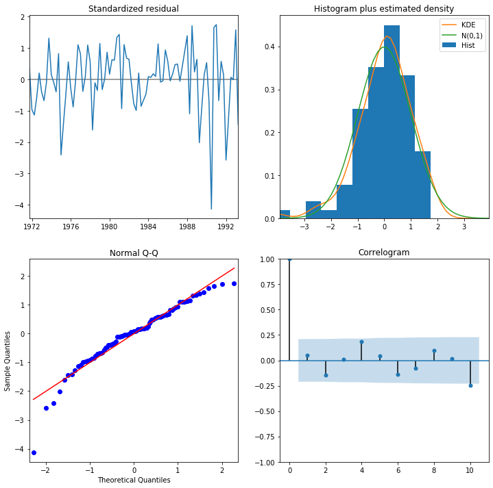

```python
# Summarize residual errors for the chosen ARIMA model
model = SARIMAX(series, order=ns_order, seasonal_order=ss_order, trend='c')
results = model.fit()
print(results.summary())
results.plot_diagnostics(figsize=(12,12))
plt.show()
```

```python
if (notifyStatus): email_notify("Model Fitting and Evaluation completed! "+datetime.now().strftime('%a %B %d, %Y %I:%M:%S %p'))
```

## Section 5. Finalize Model

After models have been developed and a final model selected, it must be validated and finalized. Validation is an optional part of the process, but one that provides a ‘last check’ to ensure we have not fooled or lied to ourselves.

```python
if (notifyStatus): email_notify("Model Finalization has begun! "+datetime.now().strftime('%a %B %d, %Y %I:%M:%S %p'))
```

### 5.a) Validation via In-sample Data

```python
model = SARIMAX(series, order=ns_order, seasonal_order=ss_order, trend='c')
results = model.fit()
forecast = results.get_prediction(start = -test_size)
mean_forecast = forecast.predicted_mean
confidence_intervals = forecast.conf_int()
```

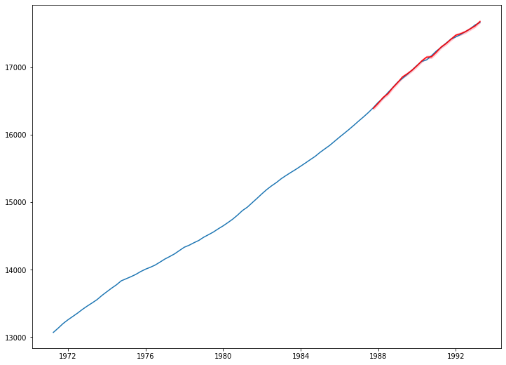

```python
plt.figure(figsize=(12,9))
plt.plot(series.index, series[target_col], label='observed')
plt.plot(mean_forecast.index, mean_forecast.values, color='red', label='forecast')
plt.fill_between(confidence_intervals.index, confidence_intervals[lower_bound], confidence_intervals[upper_bound], color='pink')
plt.show()
```

```python
# Evaluate RMSE for the validation data
y = series[-test_size:]
predictions = mean_forecast.values
rmse = math.sqrt(mean_squared_error(y, predictions))
print('RMSE from the validation data is: %.3f' % rmse)
```

```
RMSE from the validation data is: 14.747
```

### 5.b) Forecasting Out-of-Sample Data

```python
forecast = results.get_forecast(steps = test_size)
mean_forecast = forecast.predicted_mean
confidence_intervals = forecast.conf_int()
```

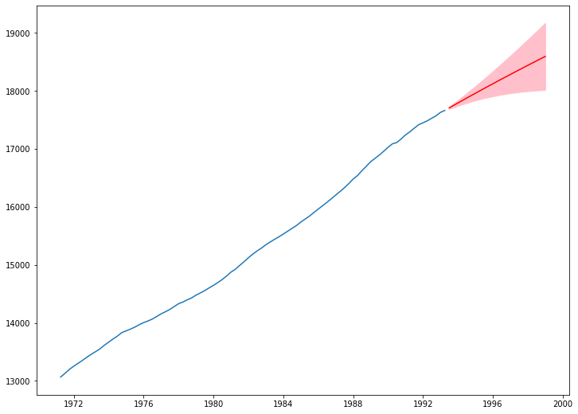

```python
plt.figure(figsize=(12,9))
plt.plot(series.index, series[target_col], label='observed')
plt.plot(mean_forecast.index, mean_forecast.values, color='red', label='forecast')
plt.fill_between(confidence_intervals.index, confidence_intervals[lower_bound], confidence_intervals[upper_bound], color='pink')
plt.show()
```

```python
if (notifyStatus): email_notify("Model Finalization completed! "+datetime.now().strftime('%a %B %d, %Y %I:%M:%S %p'))
```

```python
print ('Total time for the script:',(datetime.now() - startTimeScript))
```

```
Total time for the script: 0:00:11.346843
```